# Patel_PA3_INST447

### Imports

```python
import re
import numpy as np
import pandas as pd

# Gensim
import gensim
import gensim.corpora as corpora
from gensim.utils import simple_preprocess

# spacy for lemmatization
import spacy

# Plotting tools
import pyLDAvis

import nltk
#nltk.download('stopwords')

import warnings
warnings.filterwarnings('ignore')
```

```python
# NLTK Stop words
from nltk.corpus import stopwords
stop_words = stopwords.words('english')
stop_words.extend(['from', 'subject', 're', 'edu', 'use'])
```

```python
df=pd.read_csv('./RestaurantReviews.csv')
df.shape
df.head()
```

|  | Restaurant | Review | No_Of_Raters | Time | Cost | American | Asian | French | Indian | Mediterranean |
| --- | --- | --- | --- | --- | --- | --- | --- | --- | --- | --- |
| 0 | Beyond Flavours | The ambience was good, food was quite good . h... | 5 | 5/25/19 15:54 | 800 | 0 | 1 | 0 | 0 | 0 |
| 1 | Beyond Flavours | Ambience is too good for a pleasant evening. S... | 5 | 5/25/19 14:20 | 800 | 0 | 1 | 0 | 0 | 0 |
| 2 | Beyond Flavours | A must try.. great food great ambience. Thnx f... | 5 | 5/24/19 22:54 | 800 | 0 | 1 | 0 | 0 | 0 |
| 3 | Beyond Flavours | Soumen das and Arun was a great guy. Only beca... | 5 | 5/24/19 22:11 | 800 | 0 | 1 | 0 | 0 | 0 |
| 4 | Beyond Flavours | Food is good.we ordered Kodi drumsticks and ba... | 5 | 5/24/19 21:37 | 800 | 0 | 1 | 0 | 0 | 0 |

### Clean and tokenize the reviews

```python
# Convert to list
data = df['Review'].apply(str).tolist()

# Remove Emails
data = [re.sub('\S*@\S*\s?', '', sent) for sent in data]

# Remove new line characters
data = [re.sub('\s+', ' ', sent) for sent in data]

# Remove distracting single quotes
data = [re.sub("\'", "", sent) for sent in data]

print(data[0])
```

```
The ambience was good, food was quite good . had Saturday lunch , which was cost effective . Good place for a sate brunch. One can also chill with friends and or parents. Waiter Soumen Das was really courteous and helpful.
```

```python
# Clean and tokenize the reviews
def sent_to_words(sentences):
    for sentence in sentences:
        yield(gensim.utils.simple_preprocess(str(sentence), deacc=True))  # deacc=True removes punctuations

data_words = list(sent_to_words(data))

print('tokenized reviews', data_words[0])
```

```
tokenized reviews ['the', 'ambience', 'was', 'good', 'food', 'was', 'quite', 'good', 'had', 'saturday', 'lunch', 'which', 'was', 'cost', 'effective', 'good', 'place', 'for', 'sate', 'brunch', 'one', 'can', 'also', 'chill', 'with', 'friends', 'and', 'or', 'parents', 'waiter', 'soumen', 'das', 'was', …
```

### Create bigrams

```python
# Build the bigram models
bigram = gensim.models.Phrases(data_words, min_count=5, threshold=100) # higher threshold fewer phrases.

# Faster way to get a sentence clubbed as a trigram/bigram
bigram_mod = gensim.models.phrases.Phraser(bigram)

print(bigram_mod[data_words[4]])
```

```
['food', 'is', 'good', 'we', 'ordered', 'kodi', 'drumsticks', 'and', 'basket', 'mutton', 'biryani', 'all', 'are', 'good', 'thanks', 'to', 'pradeep', 'he', 'served', 'well', 'we', 'enjoyed', 'here', 'ambience', 'is', 'also', 'very', 'good']
```

```python
def remove_stopwords(texts):
    return [[word for word in simple_preprocess(str(doc)) if word not in stop_words] for doc in texts]

def make_bigrams(texts):
    return [bigram_mod[doc] for doc in texts]


def lemmatization(texts, allowed_postags=['NOUN', 'ADJ', 'VERB', 'ADV']):
    texts_out = []
    for sent in texts:
        doc = nlp(" ".join(sent))
        texts_out.append([token.lemma_ for token in doc if token.pos_ in allowed_postags])
    return texts_out
```

### Remove stop words and lemmatize the reviews

```python
# Remove Stop Words
data_words_nostops = remove_stopwords(data_words)

# Form Bigrams
data_words_bigrams = make_bigrams(data_words_nostops)

# Initialize spacy 'en' model, keeping only tagger component (for efficiency)
# python3 -m spacy download en
nlp = spacy.load('en', disable=['parser', 'ner'])
# Do lemmatization keeping only noun, adj, vb, adv
data_lemmatized = lemmatization(data_words_bigrams, allowed_postags=['NOUN', 'ADJ', 'VERB', 'ADV'])

print(data_lemmatized[0])
```

```
['good', 'food', 'quite', 'good', 'lunch', 'cost_effective', 'good', 'place', 'sate', 'brunch', 'also', 'chill', 'friend', 'parent', 'waiter', 'really', 'courteous', 'helpful']
```

```python
# Create Dictionary
id2word = corpora.Dictionary(data_lemmatized)

# Create Corpus
texts = data_lemmatized

# Term Document Frequency
corpus = [id2word.doc2bow(text) for text in texts]

# View
print(corpus[0])
```

```
[(0, 1), (1, 1), (2, 1), (3, 1), (4, 1), (5, 1), (6, 1), (7, 3), (8, 1), (9, 1), (10, 1), (11, 1), (12, 1), (13, 1), (14, 1), (15, 1)]
```

### LDA to develop a topic model with 3 topics

```python
lda_model = gensim.models.ldamodel.LdaModel(corpus=corpus,
                                           id2word=id2word,
                                           num_topics=3,
                                           random_state=100,
                                           update_every=1,
                                           chunksize=100,
                                           passes=10,
                                           alpha='auto',
                                           per_word_topics=True)
# Print the KeywordS in the 20 topics
print(lda_model.print_topics())
doc_lda = lda_model[corpus]
```

```
[(0, '0.087*"good" + 0.076*"food" + 0.065*"place" + 0.034*"service" + 0.022*"great" + 0.021*"visit" + 0.019*"staff" + 0.018*"really" + 0.015*"ambience" + 0.015*"go"'), (1, '0.034*"order" + 0.021*"restaurant" + 0.018*"get" + 0.016*"bad" + 0.013*"even" + 0.013*"take" + 0.012*"give" + 0.012*"say" + 0.0…
```

### Visualization of the topic models

```python
import pyLDAvis.gensim_models
pyLDAvis.enable_notebook()
vis = pyLDAvis.gensim_models.prepare(lda_model, corpus, id2word)
vis
```

[interactive chart not shown]

### Discuss your findings from the topic model

The theme for the first, second, and third topic are positive, neutral, and negative respectively. What I found the most interesting is how the composition of a positive rating is more than just the quality of the food it also involves the environment and the quality of service. With that being said, I also noticed how the negative ones had words that relate to poor service like "wait" show up frequently.

### Resample and sum up the American, French, Indian, Asian, and Mediterranean columns quarterly

```python
df['Time'] = pd.to_datetime(df['Time'])
df = df.set_index('Time')
df.head()
```

| Time | Restaurant | Review | No_Of_Raters | Cost | American | Asian | French | Indian | Mediterranean |
| --- | --- | --- | --- | --- | --- | --- | --- | --- | --- |
| 2019-05-25 15:54:00 | Beyond Flavours | The ambience was good, food was quite good . h... | 5 | 800 | 0 | 1 | 0 | 0 | 0 |
| 2019-05-25 14:20:00 | Beyond Flavours | Ambience is too good for a pleasant evening. S... | 5 | 800 | 0 | 1 | 0 | 0 | 0 |
| 2019-05-24 22:54:00 | Beyond Flavours | A must try.. great food great ambience. Thnx f... | 5 | 800 | 0 | 1 | 0 | 0 | 0 |
| 2019-05-24 22:11:00 | Beyond Flavours | Soumen das and Arun was a great guy. Only beca... | 5 | 800 | 0 | 1 | 0 | 0 | 0 |
| 2019-05-24 21:37:00 | Beyond Flavours | Food is good.we ordered Kodi drumsticks and ba... | 5 | 800 | 0 | 1 | 0 | 0 | 0 |

```python
df_sort=df.sort_index()
df_sort.head()
df_quarterly = df_sort.resample('Q')['American','Asian','French','Indian','Mediterranean'].sum()
df_quarterly.head()
```

| Time | American | Asian | French | Indian | Mediterranean |
| --- | --- | --- | --- | --- | --- |
| 2016-06-30 | 2 | 4 | 0 | 5 | 0 |
| 2016-09-30 | 1 | 1 | 3 | 1 | 0 |
| 2016-12-31 | 5 | 1 | 2 | 17 | 1 |
| 2017-03-31 | 4 | 4 | 4 | 12 | 0 |
| 2017-06-30 | 7 | 4 | 2 | 9 | 2 |

### Plot them all in a single plot

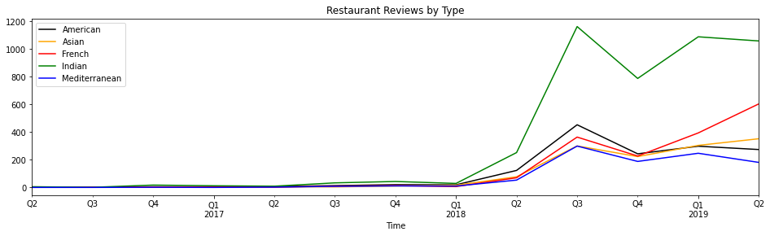

```python
plot_kwargs = dict(figsize=(16,4),color=['black', 'orange', 'red', 'green', 'blue'],title='Restaurant Reviews by Type')
df_quarterly.plot(**plot_kwargs)
```

### Observations

As we can see, the quantity of restaurant reviews began to increase for all types in Q1 of 2018. By quarter 3 we see that customers are leaving twice the amount of reviews for Indian cuisines compared to the next highest restaurant type, American. Lastly, throughout the course of the graph, we can see the difference in reviews by restaurant increases greatly from less than 10 in quarter 2 of 2016 to around 1000 in quarter 2 of 2019.